# Project1

# Part 1

Get the full dataset out of the site

# Part 2

Scatterplot showing how price evolves with living space of the flat.

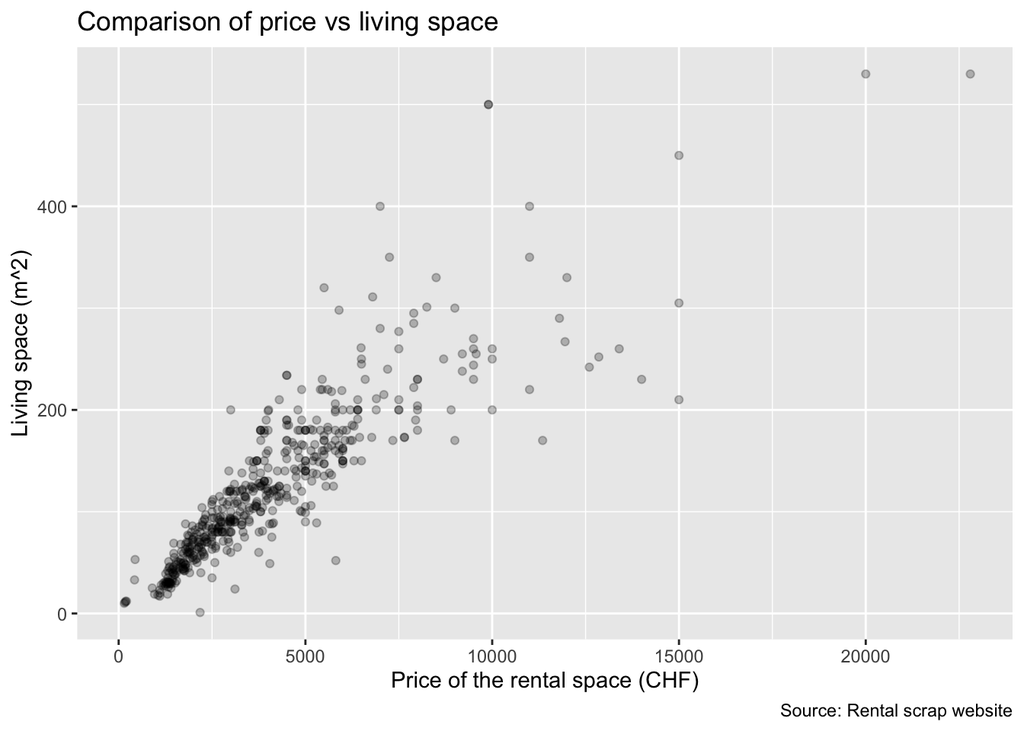

In the above scatter plot, there is a linear relationship between the two variables.

The maximum price observed for the rooms is 22800.

# Part 3

A bar plot showing the number of properties by postcode.

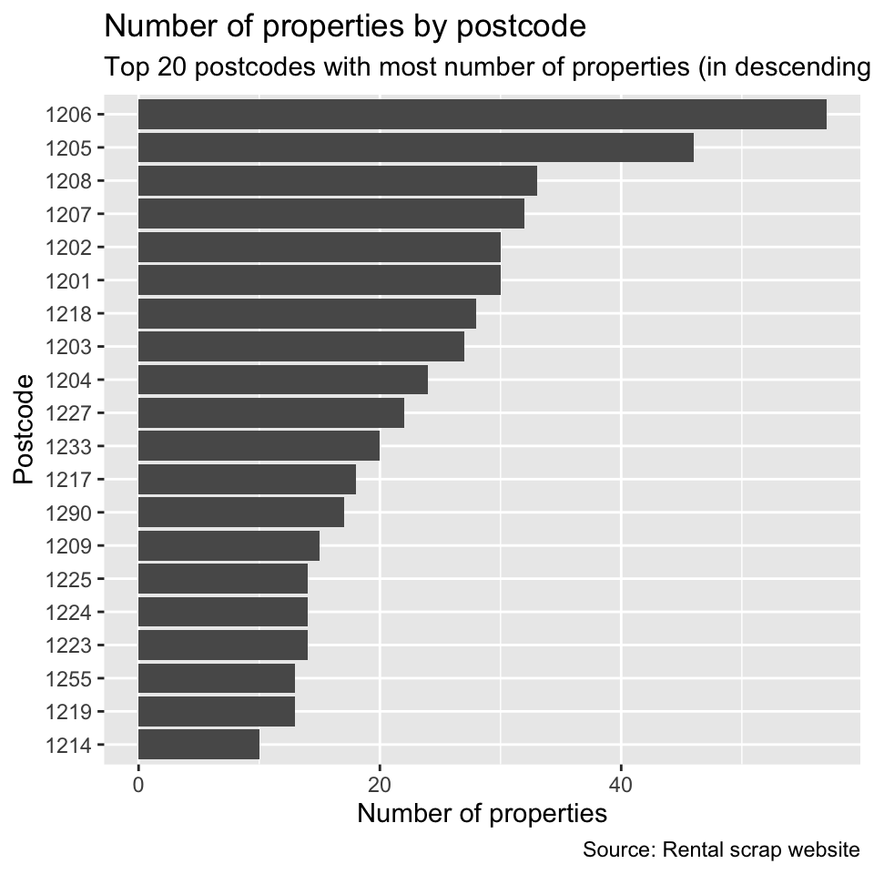

Top five postcode with most number of rooms

| location | number_property_by_postcode |
| --- | --- |
| 1206 | 57 |
| 1205 | 46 |
| 1208 | 33 |
| 1207 | 32 |
| 1201 | 30 |
| 1202 | 30 |

# Part 4

Price evolution with living space of the flat by postcode and by floor

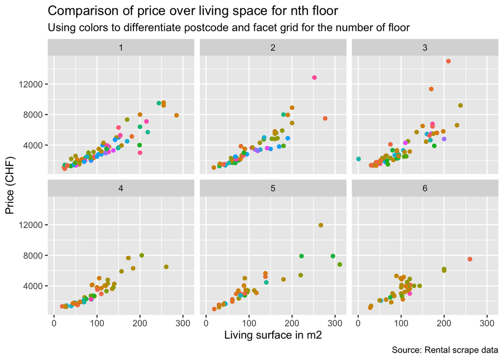

Postcode with most expensive price for nth floor

| floor | price | postcode |
| --- | --- | --- |
| 1 | 9570 | 1204 |
| 2 | 12854 | 1292 |
| 3 | 15000 | 1201 |
| 4 | 8000 | 1209 |
| 5 | 11950 | 1206 |
| 6 | 7500 | 1201 |

Postcode with least expensive price for nth floor

| floor | price | postcode |
| --- | --- | --- |
| 1 | 900 | 1201 |
| 2 | 1050 | 1204 |
| 3 | 1315 | 1203 |
| 4 | 1250 | 1205 |
| 5 | 960 | 1202 |
| 6 | 1140 | 1203 |

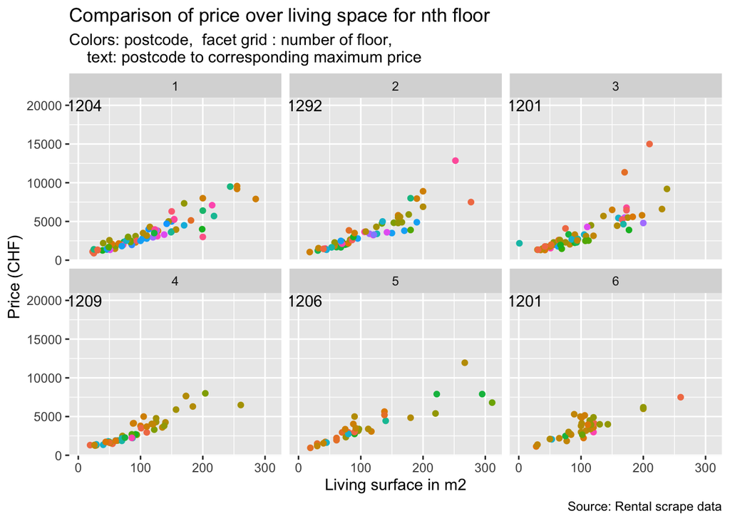

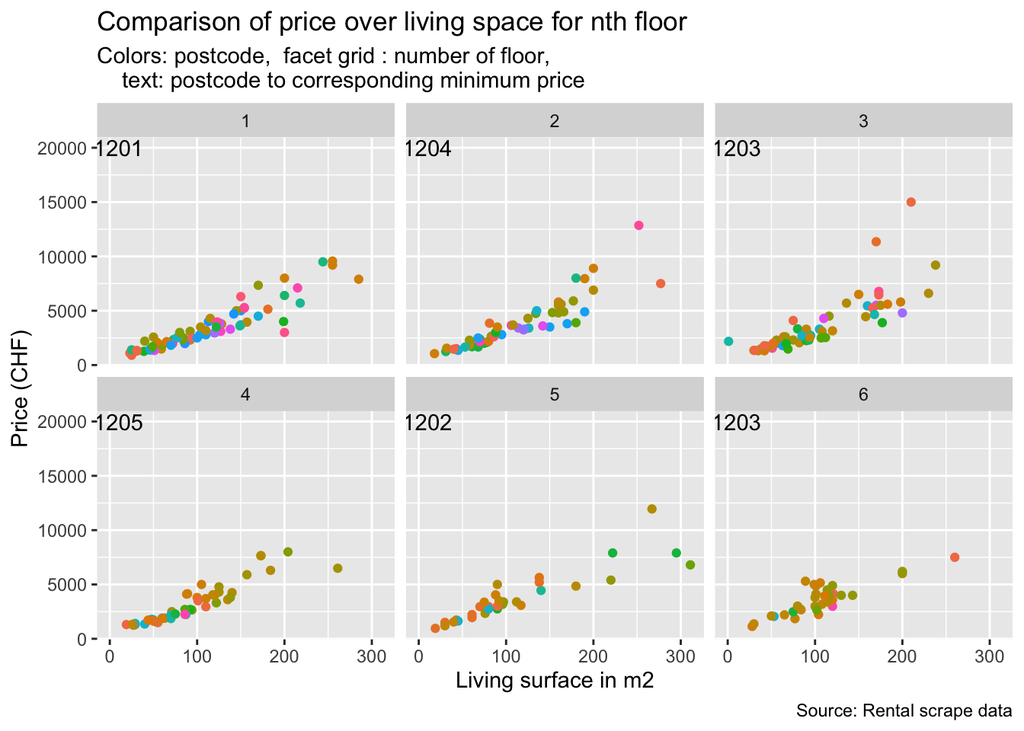

# Part 5

comparison of listings available only on demand

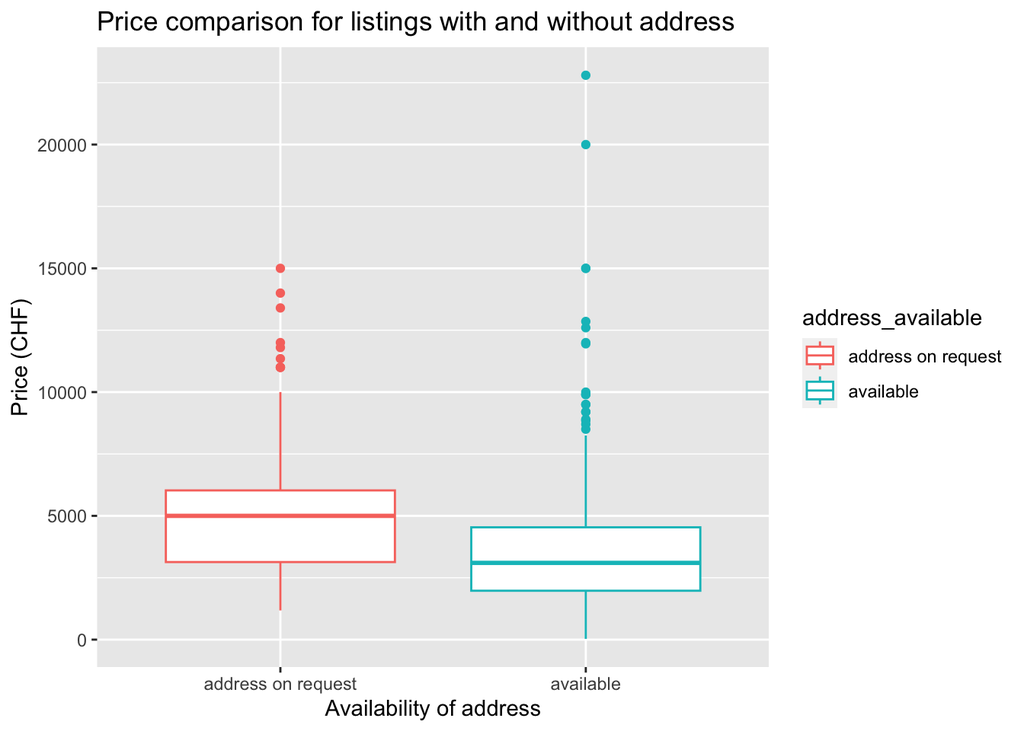

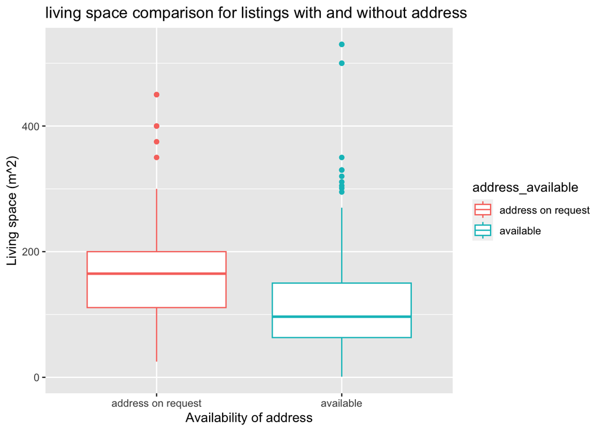

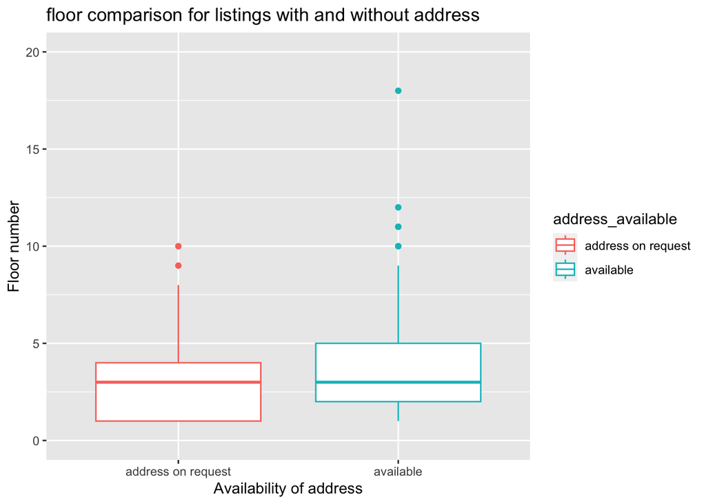

# Part 6

Comparison of variable price per square-meter

Summary table for statistics of price per square meter

| address_available | group_size | median | average | standard_deviation | maximum | minimum |
| --- | --- | --- | --- | --- | --- | --- |
| address on request | 116 | 33.33333 | 34.22823 | 9.459612 | 71.42857 | 17.500000 |
| available | 389 | 33.18182 | 34.30839 | 10.864158 | 129.75000 | 8.301887 |

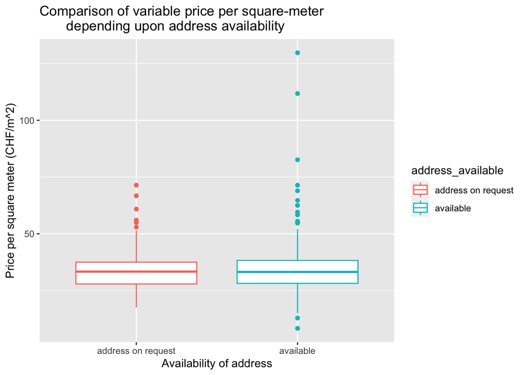

```
## # A tibble: 1 × 7
##   statistic  t_df p_value alternative estimate lower_ci upper_ci
##       <dbl> <dbl>   <dbl> <chr>          <dbl>    <dbl>    <dbl>
## 1   -0.0773  213.   0.938 two.sided    -0.0802    -2.12     1.96
```

Using the box plot, it looks price per square meter is comparable for addresses which are already available on the webiste.

After doing t-test on variable price_per_square_meter for lisitings of addresses that are classified as “address on request” and “available”, it can be observed that two groups are comparable (or similar) for the variable price per square meter. This conclusion was deduced by looking at the box plot and also checking the p-value from the t-test.

# Part 7

Comparison of variable price

Summary table for statistics of price

| address_available | group_size | median | average | standard_deviation | maximum | minimum |
| --- | --- | --- | --- | --- | --- | --- |
| address on request | 116 | 5000 | 5424.043 | 2758.809 | 15000 | 1200 |
| available | 389 | 3150 | 3761.468 | 2601.303 | 22800 | 150 |

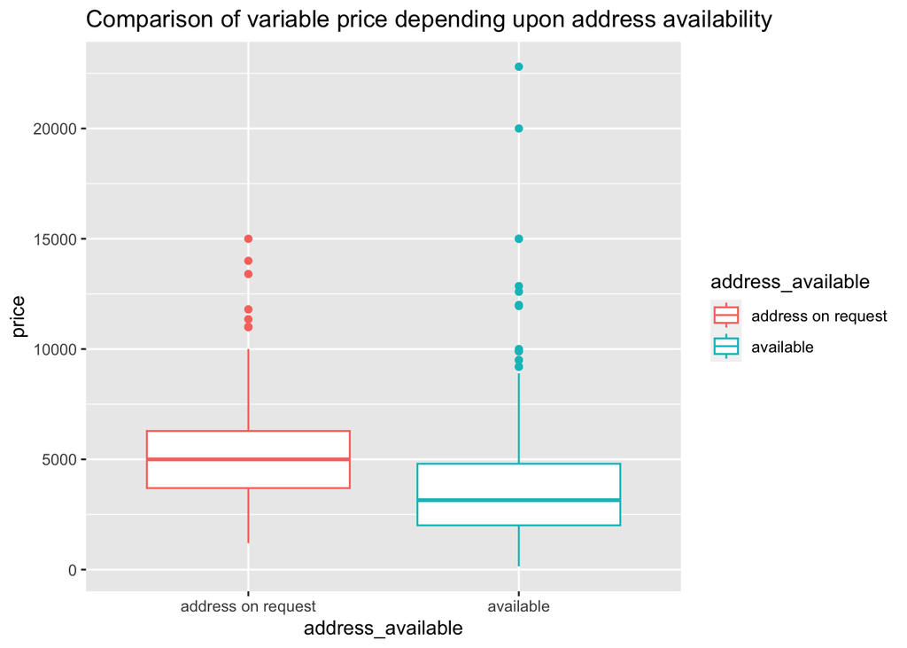

```
## # A tibble: 1 × 7
##   statistic  t_df       p_value alternative estimate lower_ci upper_ci
##       <dbl> <dbl>         <dbl> <chr>          <dbl>    <dbl>    <dbl>
## 1      5.96   503 0.00000000483 two.sided      1663.    1114.    2211.
```

From the box plot of price with address availability, it looks like “addresses on request” have higher price compared to addresses which are already “available” on the website. So the comparison result does change for variables “price per squre meter” and “price”

# Part 8